# q2

# 1.

Load the Alzheimer’s disease data using the commands:

library(AppliedPredictiveModeling) data(AlzheimerDisease) Which of the following commands will create training and test sets with about 50% of the observations assigned to each?

```r
#install.packages("AppliedPredictiveModeling")
library(AppliedPredictiveModeling)
#install.packages("caret")
library(caret)
data(AlzheimerDisease)

adData = data.frame(diagnosis,predictors)
trainIndex = createDataPartition(diagnosis, p = 0.50,list=FALSE)
training = adData[trainIndex,]
testing = adData[-trainIndex,]
dim(testing); dim(training)
```

```
## [1] 166 131
```

```
## [1] 167 131
```

```r
#OK
# adData = data.frame(diagnosis,predictors)
# train = createDataPartition(diagnosis, p = 0.50,list=FALSE)
# test = createDataPartition(diagnosis, p = 0.50,list=FALSE)
# dim(test); dim(train)
#NO OK
# adData = data.frame(diagnosis,predictors)
# trainIndex = createDataPartition(diagnosis, p = 0.50)
# training = adData[trainIndex,]
# testing = adData[-trainIndex,]
# dim(testing); dim(training)
#NO OK
adData = data.frame(predictors)
trainIndex = createDataPartition(diagnosis,p=0.5,list=FALSE)
training = adData[trainIndex,]
testing = adData[-trainIndex,]
dim(testing); dim(training)
```

```
## [1] 166 130
```

```
## [1] 167 130
```

```r
#NO OK, falta el diagnostics

adData = data.frame(diagnosis,predictors)
testIndex = createDataPartition(diagnosis, p = 0.50,list=FALSE)
training = adData[-testIndex,]
testing = adData[testIndex,]
dim(testing); dim(training)
```

```
## [1] 167 131
```

```
## [1] 166 131
```

```r
adData = data.frame(diagnosis,predictors)
trainIndex = createDataPartition(diagnosis,p=0.5,list=FALSE)
training = adData[trainIndex,]
testing = adData[-trainIndex,]
dim(testing); dim(training)
```

```
## [1] 166 131
```

```
## [1] 167 131
```

```r
adData = data.frame(diagnosis,predictors)
train = createDataPartition(diagnosis, p = 0.50,list=FALSE)
test = createDataPartition(diagnosis, p = 0.50,list=FALSE)
dim(test); dim(train)
```

```
## [1] 167   1
```

```
## [1] 167   1
```

```r
dim(testing); dim(training)
```

```
## [1] 166 131
```

```
## [1] 167 131
```

# 2.

Load the cement data using the commands:

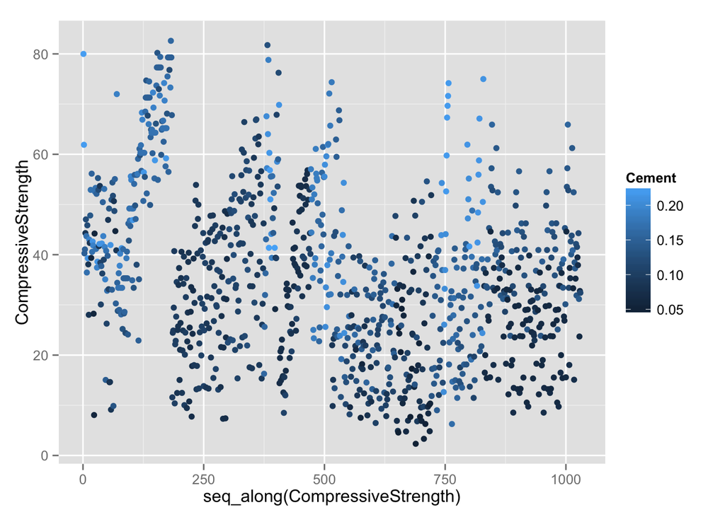

```r
#install.packages("AppliedPredictiveModeling")
library(AppliedPredictiveModeling)
data(concrete)
library(caret)
set.seed(1000)
inTrain = createDataPartition(mixtures$CompressiveStrength, p = 3/4)[[1]]
training = mixtures[ inTrain,]
testing = mixtures[-inTrain,]
g <- qplot(data = mixtures, y = CompressiveStrength, color = Cement)
g
```

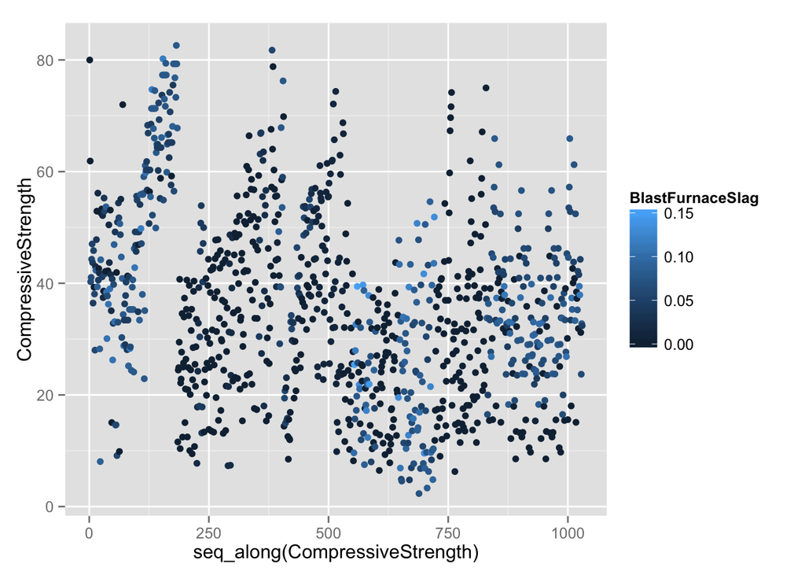

```r
g <- qplot(data = mixtures, y = CompressiveStrength, color = BlastFurnaceSlag)
g
```

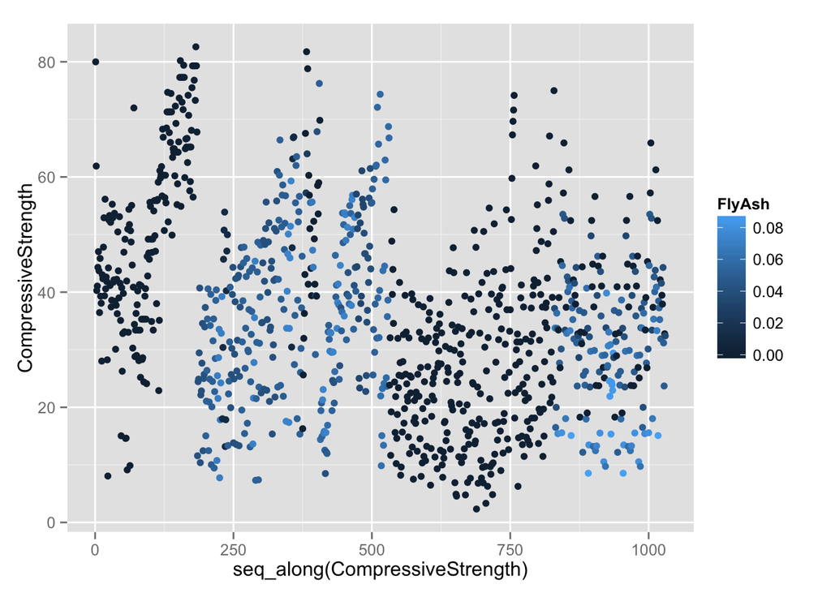

```r
g <- qplot(data = mixtures, y = CompressiveStrength, color = FlyAsh)
g
```

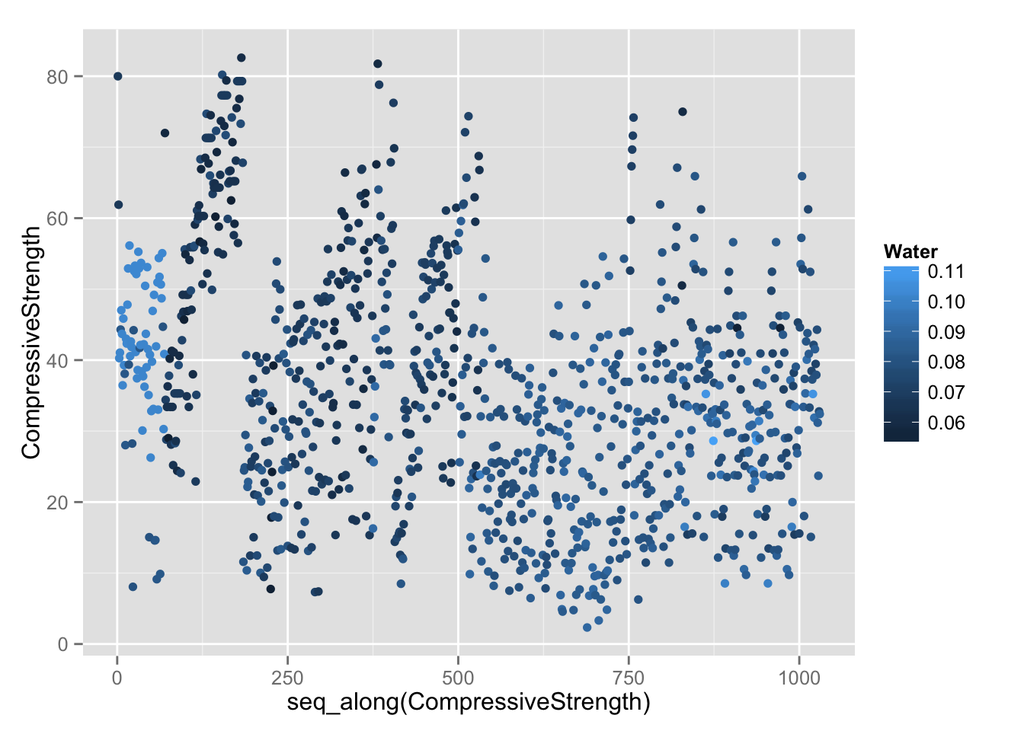

```r
g <- qplot(data = mixtures, y = CompressiveStrength, color = Water)
g
```

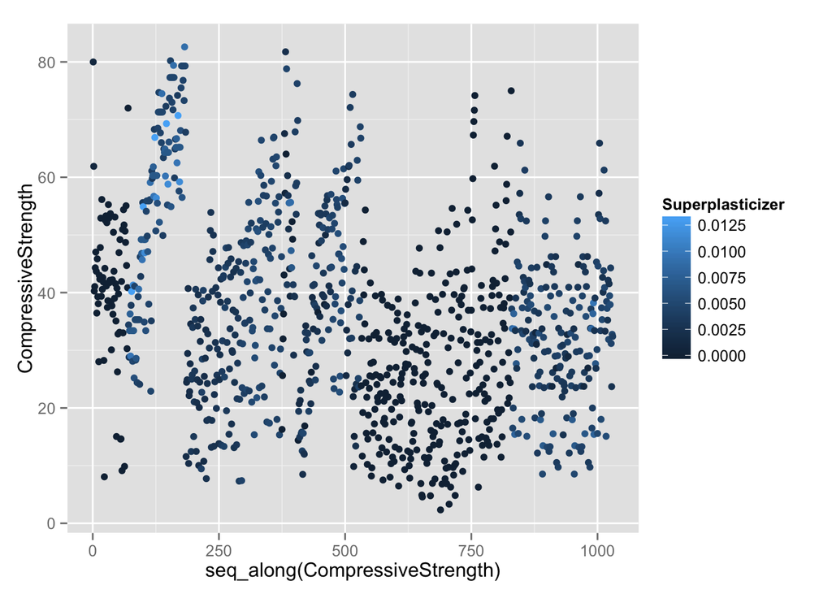

```r
g <- qplot(data = mixtures, y = CompressiveStrength, color = Superplasticizer)
g
```

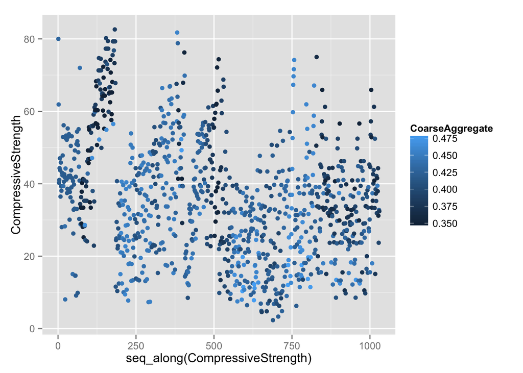

```r
g <- qplot(data = mixtures, y = CompressiveStrength, color = CoarseAggregate)
g
```

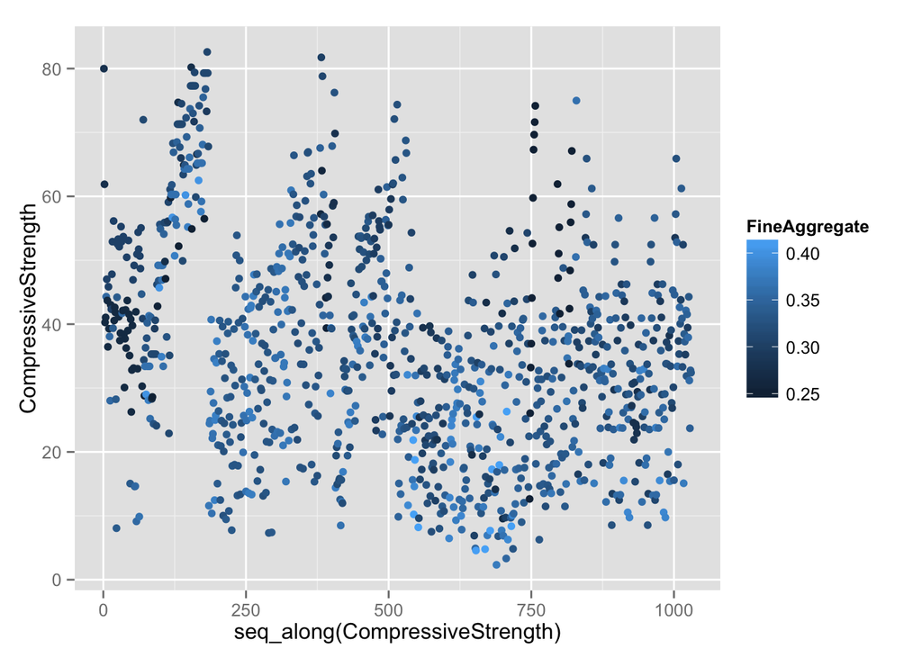

```r
g <- qplot(data = mixtures, y = CompressiveStrength, color = FineAggregate)
g
```

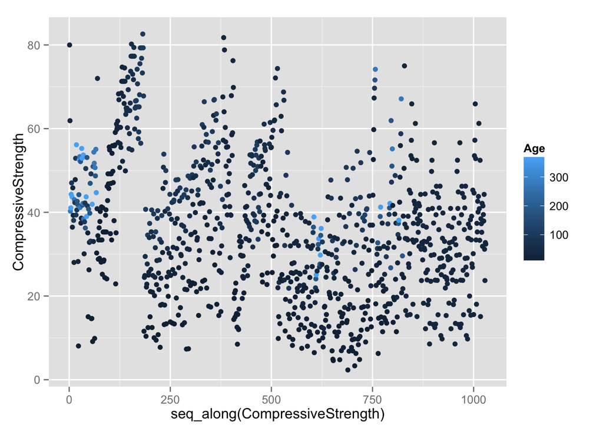

```r
g <- qplot(data = mixtures, y = CompressiveStrength, color = Age)
g
```

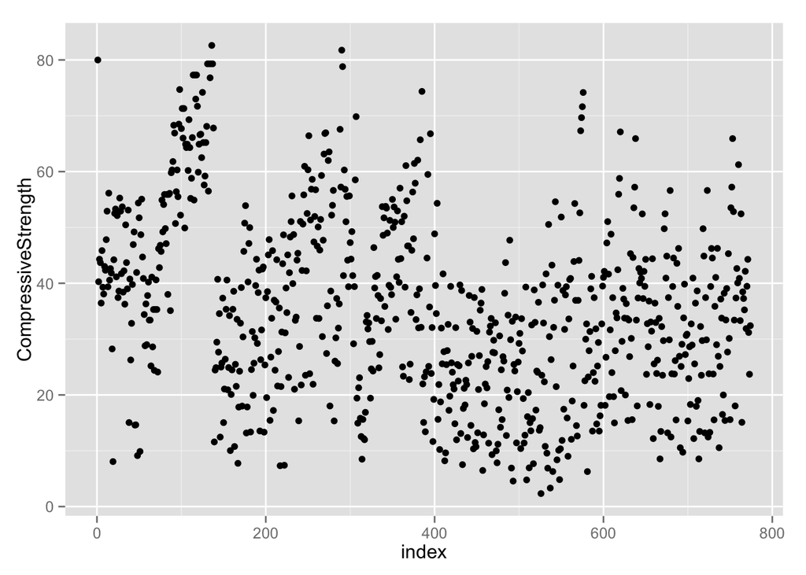

```r
index <- seq_along(1:nrow(training))
p <- ggplot(data = training, aes(x = index, y = CompressiveStrength)) + geom_point()
p
```

```r
summary(mixtures)
```

```
##      Cement        BlastFurnaceSlag       FlyAsh            Water
##  Min.   :0.04482   Min.   :0.000000   Min.   :0.00000   Min.   :0.05139
##  1st Qu.:0.08206   1st Qu.:0.000000   1st Qu.:0.00000   1st Qu.:0.06954
##  Median :0.11528   Median :0.009455   Median :0.00000   Median :0.07862
##  Mean   :0.11955   Mean   :0.031643   Mean   :0.02317   Mean   :0.07773
##  3rd Qu.:0.14917   3rd Qu.:0.061972   3rd Qu.:0.05034   3rd Qu.:0.08386
##  Max.   :0.22541   Max.   :0.150339   Max.   :0.08884   Max.   :0.11222
##  Superplasticizer   CoarseAggregate  FineAggregate         Age
##  Min.   :0.000000   Min.   :0.3459   Min.   :0.2480   Min.   :  1.00
##  1st Qu.:0.000000   1st Qu.:0.3923   1st Qu.:0.3112   1st Qu.:  7.00
##  Median :0.002727   Median :0.4205   Median :0.3305   Median : 28.00
##  Mean   :0.002621   Mean   :0.4152   Mean   :0.3301   Mean   : 45.66
##  3rd Qu.:0.004351   3rd Qu.:0.4376   3rd Qu.:0.3541   3rd Qu.: 56.00
##  Max.   :0.013149   Max.   :0.4798   Max.   :0.4141   Max.   :365.00
##  CompressiveStrength
##  Min.   : 2.33
##  1st Qu.:23.71
##  Median :34.45
##  Mean   :35.82
##  3rd Qu.:46.13
##  Max.   :82.60
```

Make a plot of the outcome (CompressiveStrength) versus the index of the samples. Color by each of the variables in the data set (you may find the cut2() function in the Hmisc package useful for turning continuous covariates into factors). What do you notice in these plots?

There is a non-random pattern in the plot of the outcome versus index that is perfectly explained by the FlyAsh variable so there may be a variable missing.

There is a non-random pattern in the plot of the outcome versus index.

There is a non-random pattern in the plot of the outcome versus index that is perfectly explained by the Age variable so there may be a variable missing.

–> There is a non-random pattern in the plot of the outcome versus index that does not appear to be perfectly explained by any predictor suggesting a variable may be missing.

3. Load the cement data using the commands:

```r
library(AppliedPredictiveModeling)
data(concrete)
library(caret)
set.seed(1000)
inTrain = createDataPartition(mixtures$CompressiveStrength, p = 3/4)[[1]]
training = mixtures[ inTrain,]
testing = mixtures[-inTrain,]
summary(training)
```

```
##      Cement        BlastFurnaceSlag       FlyAsh            Water
##  Min.   :0.04482   Min.   :0.000000   Min.   :0.00000   Min.   :0.05139
##  1st Qu.:0.08179   1st Qu.:0.000000   1st Qu.:0.00000   1st Qu.:0.06972
##  Median :0.11462   Median :0.009993   Median :0.00000   Median :0.07862
##  Mean   :0.11782   Mean   :0.032051   Mean   :0.02247   Mean   :0.07774
##  3rd Qu.:0.14793   3rd Qu.:0.061968   3rd Qu.:0.04999   3rd Qu.:0.08384
##  Max.   :0.22541   Max.   :0.150339   Max.   :0.08884   Max.   :0.11222
##  Superplasticizer   CoarseAggregate  FineAggregate         Age
##  Min.   :0.000000   Min.   :0.3459   Min.   :0.2480   Min.   :  1.00
##  1st Qu.:0.000000   1st Qu.:0.3986   1st Qu.:0.3113   1st Qu.: 14.00
##  Median :0.002726   Median :0.4213   Median :0.3305   Median : 28.00
##  Mean   :0.002608   Mean   :0.4167   Mean   :0.3306   Mean   : 47.46
##  3rd Qu.:0.004351   3rd Qu.:0.4389   3rd Qu.:0.3542   3rd Qu.: 56.00
##  Max.   :0.013149   Max.   :0.4798   Max.   :0.4141   Max.   :365.00
##  CompressiveStrength
##  Min.   : 2.33
##  1st Qu.:23.71
##  Median :34.48
##  Mean   :35.64
##  3rd Qu.:46.13
##  Max.   :82.60
```

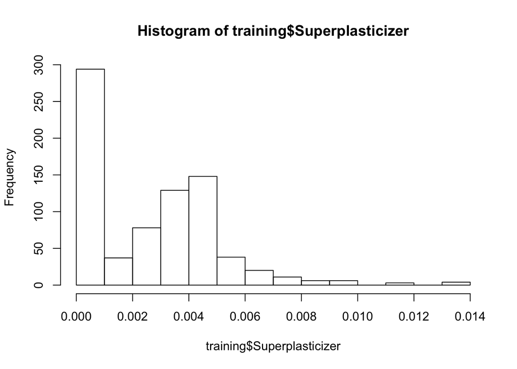

```r
hist(training$Superplasticizer)
```

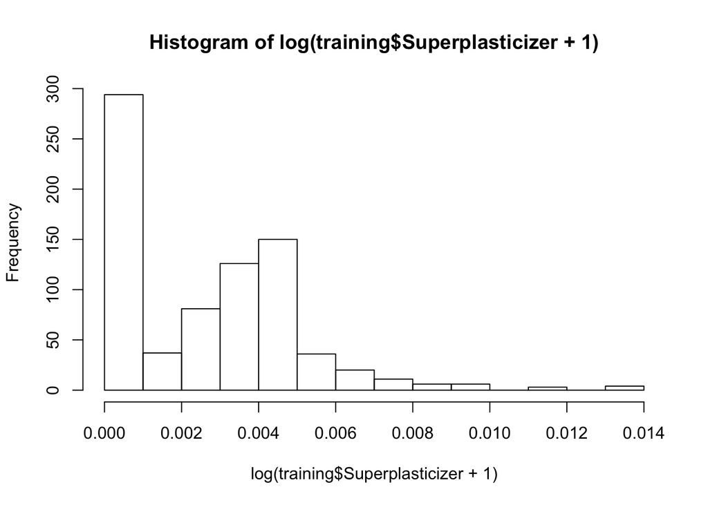

```r
hist(log(training$Superplasticizer+1))
```

Make a histogram and confirm the SuperPlasticizer variable is skewed. Normally you might use the log transform to try to make the data more symmetric. Why would that be a poor choice for this variable?

The SuperPlasticizer data include negative values so the log transform can not be performed.

The log transform produces negative values which can not be used by some classifiers.

The log transform does not reduce the skewness of the non-zero values of SuperPlasticizer

–> There are values of zero so when you take the log() transform those values will be -Inf.

# 4.

Load the Alzheimer’s disease data using the commands:

```r
library(caret)
library(AppliedPredictiveModeling)
set.seed(3433)
data(AlzheimerDisease)
adData = data.frame(diagnosis,predictors)
inTrain = createDataPartition(adData$diagnosis, p = 3/4)[[1]]
training = adData[ inTrain,]
testing = adData[-inTrain,]
summary(training)
```

```
##     diagnosis   ACE_CD143_Angiotensin_Converti
##  Impaired: 69   Min.   :-0.6756
##  Control :182   1st Qu.: 0.9462
##                 Median : 1.3013
##                 Mean   : 1.3056
##                 3rd Qu.: 1.6808
##                 Max.   : 3.0890
##  ACTH_Adrenocorticotropic_Hormon      AXL           Adiponectin
##  Min.   :-2.207                  Min.   :-0.9230   Min.   :-7.059
##  1st Qu.:-1.715                  1st Qu.:-0.0201   1st Qu.:-5.745
##  Median :-1.514                  Median : 0.2804   Median :-5.221
##  Mean   :-1.537                  Mean   : 0.2791   Mean   :-5.241
##  3rd Qu.:-1.347                  3rd Qu.: 0.6077   3rd Qu.:-4.816
##  Max.   :-0.844                  Max.   : 1.2863   Max.   :-3.474
##  Alpha_1_Antichymotrypsin Alpha_1_Antitrypsin Alpha_1_Microglobulin
##  Min.   :0.1823           Min.   :-18.173     Min.   :-4.343
##  1st Qu.:1.0986           1st Qu.:-14.135     1st Qu.:-3.297
##  Median :1.3610           Median :-13.104     Median :-2.976
##  Mean   :1.3348           Mean   :-13.169     Mean   :-2.960
##  3rd Qu.:1.5789           3rd Qu.:-12.135     3rd Qu.:-2.590
##  Max.   :2.3026           Max.   : -8.192     Max.   :-1.772
##  Alpha_2_Macroglobulin Angiopoietin_2_ANG_2 Angiotensinogen
##  Min.   :-289.7        Min.   :-0.5447      Min.   :1.710
##  1st Qu.:-186.6        1st Qu.: 0.4700      1st Qu.:2.107
##  Median :-165.8        Median : 0.6419      Median :2.320
##  Mean   :-160.8        Mean   : 0.6524      Mean   :2.312
##  3rd Qu.:-136.5        3rd Qu.: 0.8329      3rd Qu.:2.480
##  Max.   : -71.7        Max.   : 1.5261      Max.   :2.862
##  Apolipoprotein_A_IV Apolipoprotein_A1 Apolipoprotein_A2 Apolipoprotein_B
##  Min.   :-2.957      Min.   :-8.680    Min.   :-1.9661   Min.   :-9.937
##  1st Qu.:-2.120      1st Qu.:-7.849    1st Qu.:-0.9809   1st Qu.:-6.748
##  Median :-1.897      Median :-7.488    Median :-0.6931   Median :-5.780
##  Mean   :-1.878      Mean   :-7.509    Mean   :-0.6613   Mean   :-5.671
##  3rd Qu.:-1.609      3rd Qu.:-7.222    3rd Qu.:-0.3496   3rd Qu.:-4.603
##  Max.   :-0.821      Max.   :-6.166    Max.   : 0.9555   Max.   :-2.153
##  Apolipoprotein_CI Apolipoprotein_CIII Apolipoprotein_D Apolipoprotein_E
##  Min.   :-3.3242   Min.   :-3.863      Min.   :0.2624   Min.   :0.5911
##  1st Qu.:-1.8326   1st Qu.:-2.797      1st Qu.:1.1939   1st Qu.:2.2591
##  Median :-1.6094   Median :-2.564      Median :1.4110   Median :2.7857
##  Mean   :-1.6074   Mean   :-2.511      Mean   :1.4206   Mean   :2.7671
```

[output cut: 218 more lines]

```
##  Max.   :-2.957        Max.   :3.689   Max.   :22.38   Max.   : 0.53063
##  von_Willebrand_Factor      age              tau            p_tau
##  Min.   :-4.991        Min.   :0.9834   Min.   :4.535   Min.   :2.964
##  1st Qu.:-4.200        1st Qu.:0.9850   1st Qu.:5.350   1st Qu.:3.727
##  Median :-3.912        Median :0.9861   Median :5.792   Median :4.046
##  Mean   :-3.917        Mean   :0.9860   Mean   :5.761   Mean   :4.028
##  3rd Qu.:-3.612        3rd Qu.:0.9871   3rd Qu.:6.166   3rd Qu.:4.352
##  Max.   :-2.957        Max.   :0.9897   Max.   :7.093   Max.   :5.330
##      Ab_42             male        Genotype
##  Min.   : 8.879   Min.   :0.0000   E2E2:  2
##  1st Qu.:11.216   1st Qu.:0.0000   E2E3: 29
##  Median :12.435   Median :0.0000   E2E4:  6
##  Mean   :12.416   Mean   :0.4064   E3E3:121
##  3rd Qu.:13.634   3rd Qu.:1.0000   E3E4: 83
##  Max.   :15.956   Max.   :1.0000   E4E4: 10
```

```r
training_sub <- training[grepl("IL", names(training))]
preProc <- preProcess(training_sub,method="pca",thresh = .90)
```

Find all the predictor variables in the training set that begin with IL. Perform principal components on these variables with the preProcess() function from the caret package. Calculate the number of principal components needed to capture 80% of the variance. How many are there?

12

11

–> 7

8

5. Load the Alzheimer’s disease data using the commands:

```
## [1] 333 131
```

```
## [1] 333  13
```

```
##
## Call:
## NULL
##
## Deviance Residuals:
##     Min       1Q   Median       3Q      Max
## -2.3622  -0.9578   0.5826   0.8143   1.4541
##
## Coefficients:
##                Estimate Std. Error z value Pr(>|z|)
## (Intercept)     4.61838   25.00307   0.185  0.85345
## IL_11          -0.06047    0.11270  -0.537  0.59155
## IL_13          10.06638   17.33496   0.581  0.56144
## IL_16          -0.63715    0.41335  -1.541  0.12321
## IL_17E          0.32357    0.13196   2.452  0.01421 *
## IL_1alpha      -0.49033    0.43477  -1.128  0.25941
## IL_3            0.76931    0.55224   1.393  0.16360
## IL_4           -0.20307    0.37676  -0.539  0.58990
## IL_5            0.12058    0.52422   0.230  0.81808
## IL_6            0.11164    0.27985   0.399  0.68994
## IL_6_Receptor  -0.33689    0.53219  -0.633  0.52672
## IL_7            0.55870    0.20940   2.668  0.00763 **
## IL_8          -10.43987    5.50899  -1.895  0.05808 .
## ---
## Signif. codes:  0 '***' 0.001 '**' 0.01 '*' 0.05 '.' 0.1 ' ' 1
##
## (Dispersion parameter for binomial family taken to be 1)
##
##     Null deviance: 295.21  on 250  degrees of freedom
## Residual deviance: 267.52  on 238  degrees of freedom
## AIC: 293.52
##
## Number of Fisher Scoring iterations: 4
```

```
##  Accuracy
## 0.6463415
```

```
##  Accuracy
## 0.7195122
```

Create a training data set consisting of only the predictors with variable names beginning with IL and the diagnosis. Build two predictive models, one using the predictors as they are and one using PCA with principal components explaining 80% of the variance in the predictors. Use method=“glm” in the train function.

What is the accuracy of each method in the test set? Which is more accurate?

–> Non-PCA Accuracy: 0.65

–> PCA Accuracy: 0.72

Non-PCA Accuracy: 0.72

PCA Accuracy: 0.71

Non-PCA Accuracy: 0.75

PCA Accuracy: 0.71

Non-PCA Accuracy: 0.72

PCA Accuracy: 0.65